# HW4

2023-01-05

**name: Zohar Attar**  
**id: 209230879**

### Instructions

1. All assignments are individual!
2. This assignment should be uploaded as two files: “rmd” and “html” (after knit) before 14/05/2023, 23:59.
3. Questions about the assignment should be asked using the Assignments forums.
4. All of the instructions of this assignment should be included in the final .html file.

```r
library(tidyverse)
library(tidymodels)
library(schrute)
library(lubridate)
library(knitr)
library(openintro)
library(ROSE)
```

In this Exersise you have the email spam train and test datasets.  
You are required to make the following:  
1) Data explanation:  
Choose five variables and explain them.  
Calculate mean median, std.  
Show frequency graph.  
Explain problems in the data (if was).  
2) Mail classification for spam or not:  
- Use logistic regression for classification  
- The goal is to get to a better solution as well as you can  
- You can use material not from this course. Explain them and why you used them.  
- Use the following evaluation metrics:  
Precision, Recall, and F1 score  
- Explain why in your opinion, this is the best solution

**1.attach - This variable represents the number of attachment in the email message.**

**line_breaks - This variable represents the number of line breaks in the email message.**

**image - This variable represents the number of images in the email message.**

**dollar - This variable represents the number of dollar signs in the email message.**

**cc - This variable represents the number of cc (carbon copies) in the email message.**

```r
vars <- train %>% select("attach", "line_breaks", "image", "dollar", "cc")

vars_mean <- sapply(vars, mean)

vars_median <- sapply(vars, median)

vars_std <- sapply(vars, sd)

vars_summary <- tibble(
  Variable = c("attach", "line_breaks", "image", "dollar", "cc"),
  Mean = vars_mean,
  Median = vars_median,
  STD = vars_std
)

vars_summary
```

```
## # A tibble: 5 × 4
##   Variable        Mean Median     STD
##   <chr>          <dbl>  <dbl>   <dbl>
## 1 attach        0.132       0   0.676
## 2 line_breaks 232.        118 327.
## 3 image         0.0525      0   0.504
## 4 dollar        1.54        0   5.13
## 5 cc            0.390       0   2.65
```

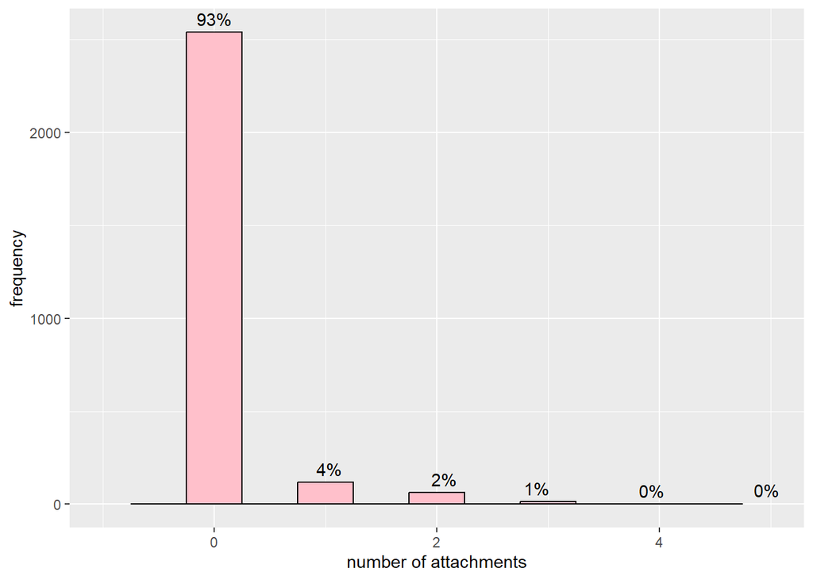

```r
ggplot(train, aes(x=attach)) +
  geom_histogram(binwidth = 0.5,fill="pink",color="black") +
  xlim(-1,5) +
  labs(x="number of attachments", y="frequency") +
  stat_bin(aes(label = ifelse(..count.. == 0, "", paste0(round((..count..)/sum(..count..)*100), "%"))),
           geom = "text", vjust = -0.5)
```

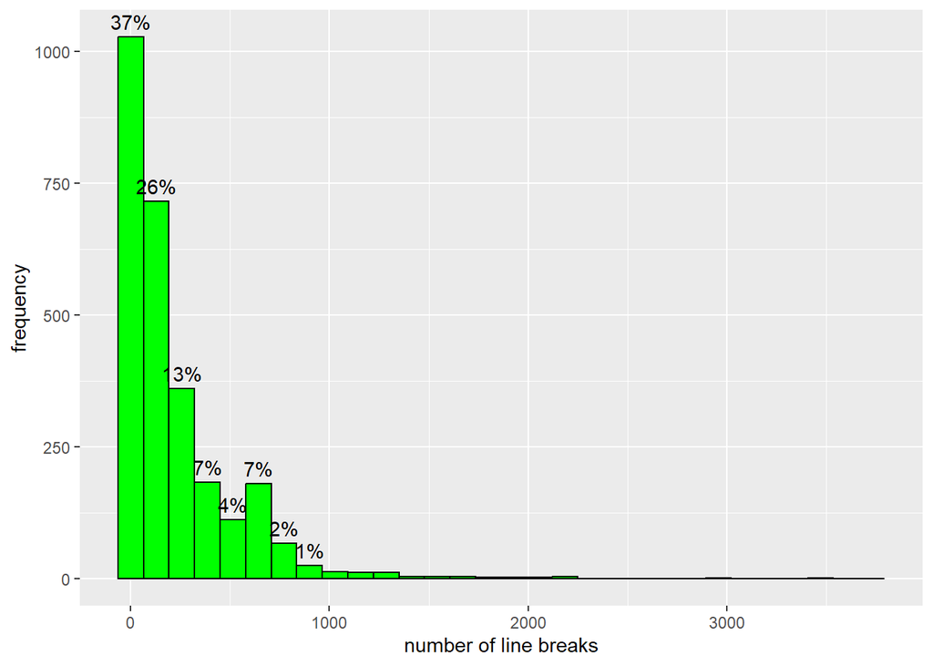

```r
ggplot(train, aes(x=line_breaks)) +
  geom_histogram(fill="green", color= "black") +
  labs(x="number of line breaks", y="frequency") +
  stat_bin(aes(label = ifelse(round((..count..)/sum(..count..)*100) == 0, "",
                              paste0(round((..count..)/sum(..count..)*100),"%"))),geom = "text", vjust = -0.5)
```

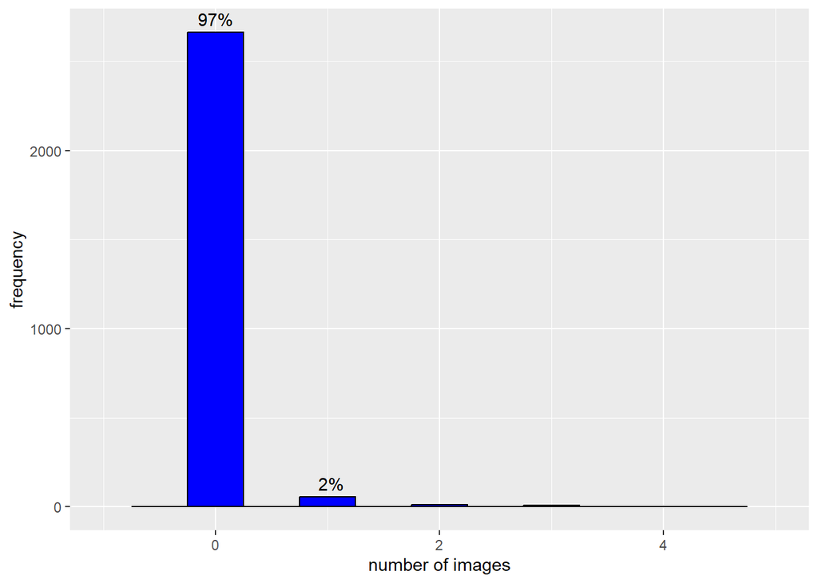

```r
ggplot(train, aes(x=image)) +
  geom_histogram(binwidth=0.5,fill="blue",color="black") +
  xlim(-1,5) +
  labs(x="number of images", y="frequency") +
  stat_bin(aes(label = ifelse(round((..count..)/sum(..count..)*100) == 0, "",
                              paste0(round((..count..)/sum(..count..)*100),"%"))),geom = "text", vjust = -0.5)
```

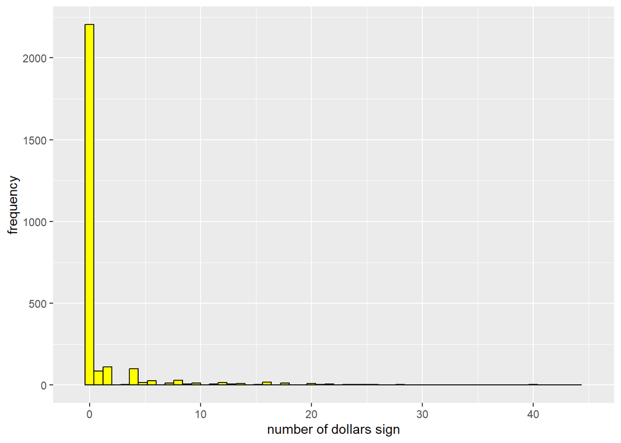

```r
ggplot(train, aes(x=dollar)) +
  geom_histogram(binwidth=0.8,fill="yellow",color="black") +
  xlim(-1,45) +
  labs(x="number of dollars sign", y="frequency")
```

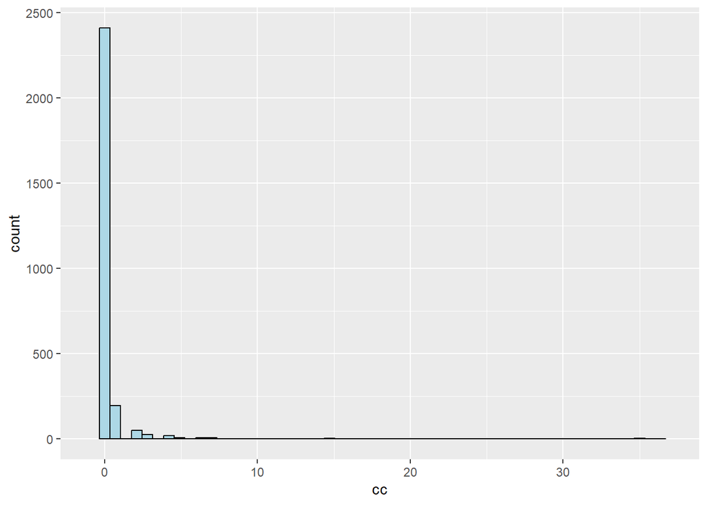

```r
ggplot(train, aes(x=cc)) +
  geom_histogram(color="black",binwidth=0.7,fill="lightblue") +
  xlim(-1,37)
```

**There are several issues with the data:**

Firstly, the “viagra” variable has only one non-zero value, which is 8, while all other values are 0. This is a problem because it could lead to incorrect results in the model and the variable may not be necessary as a feature. Moreover, we can see that also the “from” variable has the same issue - it has only two 0 values and the rest values is 1.

Secondly, the “time” variable contains both date and time information together. This makes it difficult to include it in the model and it needs to be separated into two different variables.

Finally, “num_char” and “line_breaks” variables having too many unique values it might make it difficult to detect patterns or perform analyses.

**2. logistic regression**

```r
email_rec <- recipe(spam ~ ., data = train) %>%
  step_rm(from, sent_email) %>%
  step_date(time, features = c("dow", "month")) %>%
  step_rm(time) %>%
  step_cut(cc, attach, dollar, breaks = c(0, 1)) %>%
  step_cut(inherit, password, breaks = c(0, 1, 5, 10, 20)) %>%
  step_dummy(all_nominal(), -all_outcomes()) %>%
  step_zv(all_predictors())
```

```r
email_mod <- logistic_reg() %>%
  set_engine("glm")
email_mod
```

```
## Logistic Regression Model Specification (classification)
##
## Computational engine: glm
```

```r
email_wflow <- workflow() %>%
  add_model(email_mod) %>%
  add_recipe(email_rec)
```

```r
email_fit <- email_wflow %>%
  fit(data = train)
tidy(email_fit) %>% print(n = 31)
```

```
## # A tibble: 32 × 5
##    term               estimate  std.error statistic  p.value
##    <chr>                 <dbl>      <dbl>     <dbl>    <dbl>
##  1 (Intercept)        -0.865      0.278    -3.11    1.89e- 3
##  2 image              -1.39       0.698    -2.00    4.60e- 2
##  3 viagra              2.42     300.        0.00808 9.94e- 1
##  4 num_char            0.0696     0.0266    2.62    8.85e- 3
##  5 line_breaks        -0.00625    0.00154  -4.05    5.12e- 5
##  6 exclaim_subj       -0.0297     0.274    -0.108   9.14e- 1
##  7 exclaim_mess        0.00914    0.00195   4.69    2.79e- 6
##  8 to_multiple_X1     -2.78       0.390    -7.11    1.13e-12
##  9 cc_X.1.68.         -0.908      0.568    -1.60    1.10e- 1
## 10 attach_X.1.20.      2.54       0.429     5.93    3.07e- 9
## 11 dollar_X.1.64.      0.0823     0.230     0.359   7.20e- 1
## 12 winner_yes          2.05       0.437     4.68    2.82e- 6
```

[output cut: 20 more lines]

```r
email_pred <- predict(email_fit, test) %>%
  bind_cols(test)
email_pred
```

```
## # A tibble: 1,177 × 22
##    .pred_class spam  to_multiple from     cc sent_email time
##    <fct>       <fct> <fct>       <fct> <int> <fct>      <dttm>
##  1 0           0     0           1         0 0          2012-01-01 11:09:49
##  2 0           0     0           1         0 0          2012-01-01 12:00:01
##  3 0           0     0           1         0 0          2012-01-01 23:08:59
##  4 0           0     0           1         0 0          2012-01-01 20:12:00
##  5 0           0     0           1         0 0          2012-01-02 03:58:14
##  6 0           0     0           1         0 0          2012-01-02 04:05:45
##  7 0           0     1           1         2 0          2012-01-02 20:37:38
##  8 0           0     1           1         3 0          2012-01-02 15:41:11
##  9 0           0     0           1         1 0          2012-01-02 17:12:51
## 10 0           0     0           1         0 0          2012-01-02 17:12:51
## # ℹ 1,167 more rows
## # ℹ 15 more variables: image <dbl>, attach <dbl>, dollar <dbl>, winner <fct>,
## #   inherit <dbl>, viagra <dbl>, password <dbl>, num_char <dbl>,
## #   line_breaks <int>, format <fct>, re_subj <fct>, exclaim_subj <dbl>,
## #   urgent_subj <fct>, exclaim_mess <dbl>, number <fct>
```

```r
email_pred$spam <- as.factor(email_pred$spam)
conf_matrix <- conf_mat(email_pred, truth = spam, estimate = .pred_class)
summary(conf_matrix)
```

```
## # A tibble: 13 × 3
##    .metric              .estimator .estimate
##    <chr>                <chr>          <dbl>
##  1 accuracy             binary         0.911
##  2 kap                  binary         0.226
##  3 sens                 binary         0.989
##  4 spec                 binary         0.164
##  5 ppv                  binary         0.920
##  6 npv                  binary         0.600
##  7 mcc                  binary         0.281
##  8 j_index              binary         0.152
##  9 bal_accuracy         binary         0.576
## 10 detection_prevalence binary         0.974
## 11 precision            binary         0.920
## 12 recall               binary         0.989
## 13 f_meas               binary         0.953
```

**the result of this model is:**  
precision value: 0.9196507  
recall value: 0.9887324  
F1 value: 0.9529412

```r
email_rec1 <- recipe(spam ~ ., data = train) %>%
  step_rm(from, viagra, line_breaks,exclaim_mess,num_char) %>%
  step_date(time, features = c("dow", "month")) %>%
  step_rm(time) %>%
  step_cut(cc, attach, dollar, breaks = c(0, 1)) %>%
  step_cut(inherit, password, breaks = c(0, 1, 5, 10, 20)) %>%
  step_dummy(all_nominal(), -all_outcomes()) %>%
  step_zv(all_predictors())
```

```r
email_mod1 <- logistic_reg() %>%
  set_engine("glm")
email_mod1
```

```
## Logistic Regression Model Specification (classification)
##
## Computational engine: glm
```

```r
email_wflow1 <- workflow() %>%
  add_model(email_mod1) %>%
  add_recipe(email_rec1)
```

```r
email_fit1 <- email_wflow1 %>%
  fit(data = train)
tidy(email_fit1) %>% print(n = 31)
```

```
## # A tibble: 29 × 5
##    term                estimate std.error  statistic  p.value
##    <chr>                  <dbl>     <dbl>      <dbl>    <dbl>
##  1 (Intercept)        -0.516        0.281 -1.84      6.63e- 2
##  2 image              -1.72         0.752 -2.28      2.25e- 2
##  3 exclaim_subj        0.332        0.268  1.24      2.15e- 1
##  4 to_multiple_X1     -2.77         0.415 -6.68      2.38e-11
##  5 cc_X.1.68.         -1.33         0.638 -2.08      3.74e- 2
##  6 sent_email_X1     -17.0        340.    -0.0500    9.60e- 1
##  7 attach_X.1.20.      2.75         0.517  5.32      1.02e- 7
##  8 dollar_X.1.64.     -0.0515       0.215 -0.239     8.11e- 1
##  9 winner_yes          1.64         0.411  3.98      6.92e- 5
## 10 inherit_X.1.5.     -0.329     5772.    -0.0000570 1.00e+ 0
## 11 inherit_X.5.10.     1.93         1.28   1.51      1.32e- 1
## 12 password_X.1.5.    -2.78         1.03  -2.70      6.96e- 3
```

[output cut: 17 more lines]

```r
email_pred1 <- predict(email_fit1, test) %>%
  bind_cols(test)
email_pred1
```

```
## # A tibble: 1,177 × 22
##    .pred_class spam  to_multiple from     cc sent_email time
##    <fct>       <fct> <fct>       <fct> <int> <fct>      <dttm>
##  1 0           0     0           1         0 0          2012-01-01 11:09:49
##  2 0           0     0           1         0 0          2012-01-01 12:00:01
##  3 0           0     0           1         0 0          2012-01-01 23:08:59
##  4 0           0     0           1         0 0          2012-01-01 20:12:00
##  5 0           0     0           1         0 0          2012-01-02 03:58:14
##  6 0           0     0           1         0 0          2012-01-02 04:05:45
##  7 0           0     1           1         2 0          2012-01-02 20:37:38
##  8 0           0     1           1         3 0          2012-01-02 15:41:11
##  9 0           0     0           1         1 0          2012-01-02 17:12:51
## 10 0           0     0           1         0 0          2012-01-02 17:12:51
## # ℹ 1,167 more rows
## # ℹ 15 more variables: image <dbl>, attach <dbl>, dollar <dbl>, winner <fct>,
## #   inherit <dbl>, viagra <dbl>, password <dbl>, num_char <dbl>,
## #   line_breaks <int>, format <fct>, re_subj <fct>, exclaim_subj <dbl>,
## #   urgent_subj <fct>, exclaim_mess <dbl>, number <fct>
```

```r
email_pred1$spam <- as.factor(email_pred1$spam)
conf_matrix1 <- conf_mat(email_pred1, truth = spam, estimate = .pred_class)
summary(conf_matrix1)
```

```
## # A tibble: 13 × 3
##    .metric              .estimator .estimate
##    <chr>                <chr>          <dbl>
##  1 accuracy             binary         0.921
##  2 kap                  binary         0.372
##  3 sens                 binary         0.986
##  4 spec                 binary         0.291
##  5 ppv                  binary         0.931
##  6 npv                  binary         0.681
##  7 mcc                  binary         0.412
##  8 j_index              binary         0.277
##  9 bal_accuracy         binary         0.638
## 10 detection_prevalence binary         0.96
## 11 precision            binary         0.931
## 12 recall               binary         0.986
## 13 f_meas               binary         0.958
```

**The results of the final model is:**  
precision value: 0.9308511  
recall value: 0.9859155  
F1 value: 0.9575923

**After changing the features in the model, I obtained improved results. I ran the model multiple times with different combinations of features that I mentioned before and found that this particular combination of features produces the best F1 score value.**